# Die Walküre

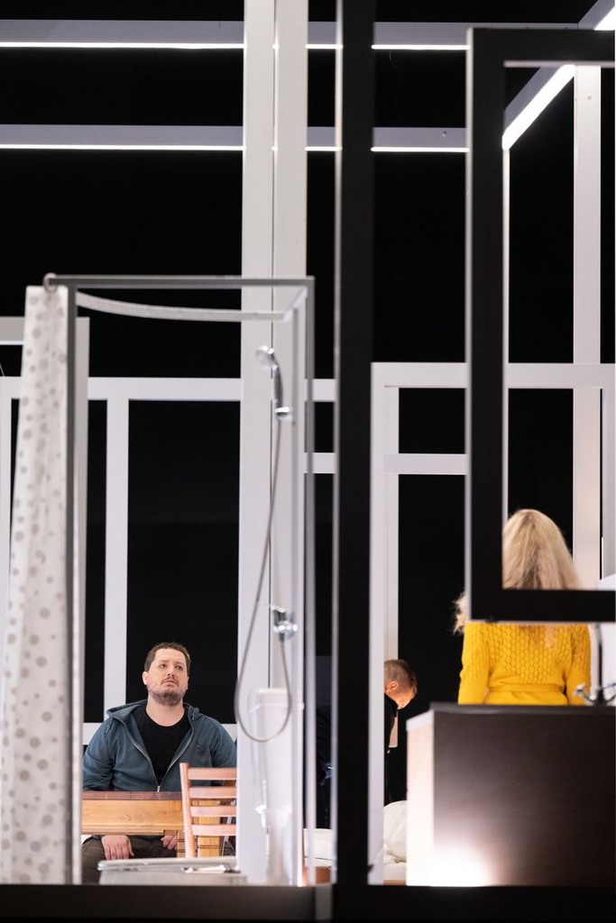

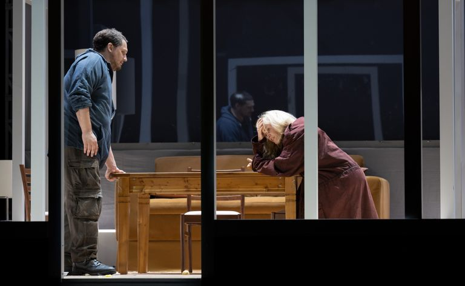

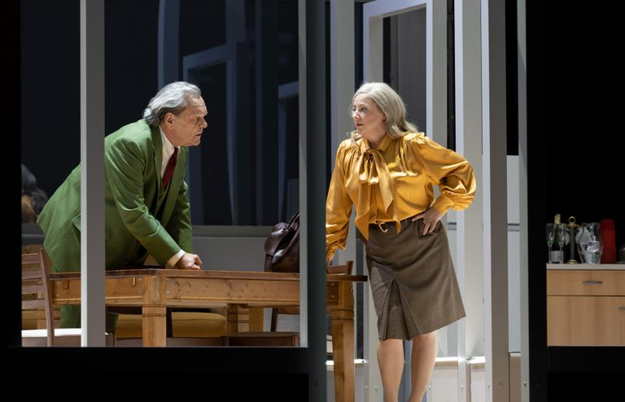

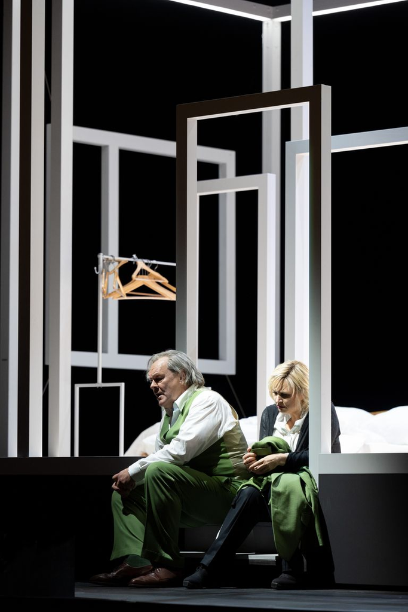

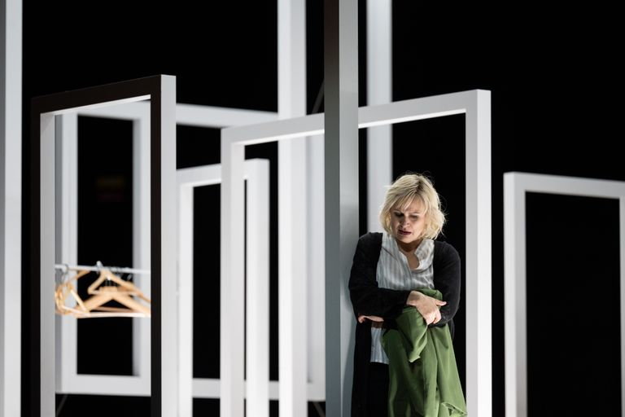

[7 more figures not shown]

## Handlung

Viele Jahre nach den Ereignissen, von denen im »Rheingold« erzählt wird

**ERSTER AUFZUG**  
Siegmund, auf der Flucht vor seinen Verfolgern, findet völlig erschöpft Zuflucht im Haus von Hunding. Hundings Frau Sieglinde bemüht sich um den Gast, damit er wieder zu sich kommt.

Der Hausherr kehrt heim und findet einen ihm Unbekannten vor. Auf Fragen antwortet der Fremde nur widerwillig, nennt auch nicht seinen Namen, sondern bezeichnet sich als Wehwalt. Er erzählt, er habe mit Vater, Mutter und Schwester im Wald gelebt; Feinde hätten sie gejagt wie wilde Wölfe und seinem Vater den Namen Wolfe gegeben. Eines Tages hätten sein Vater und er ihr Heim nicht mehr vorgefunden – die Feinde hätten das Haus niedergebrannt, die Mutter erschlagen und die Schwester mitgenommen. Bald darauf sei bei einem Kampf mit den Feinden auch der Vater verschwunden, und der Sohn sei allein geblieben. Er habe bei den Menschen leben wollen, sei aber immer gescheitert. Einmal habe er ein Mädchen schützen wollen, dass gewaltsam verheiratet werden sollte, und dessen Brüder erschlagen, doch das Mädchen habe deren Tod beweint und ihn, ihren Beschützer, verflucht. Am Ende sei sie den erzürnten Angehörigen zum Opfer gefallen und getötet worden, und er, verwundet und waffenlos, habe fliehen müssen.

Hunding hört die Geschichte und gerät in Wut: Dieser Mann ist der Feind ihres Geschlechts! Er fordert den Gast für den nächsten Morgen zum Zweikampf. Seines Sieges gewiss, denn der Gast hat ja keine Waffe, um sich zu wehren, geht Hunding ins Schlafgemach und gebietet seiner Frau, die ihm folgt, ihm seinen Schlaftrunk zu bereiten.

Siegmund, nun allein, erinnert sich sinnend, dass sein Vater ihm einst versprochen hat, in der Stunde der Not werde er ein unbesiegbares Schwert finden. Er sieht Sieglindes traurigen Blick vor sich und spürt eine große Nähe zu ihr.

Sieglinde, ebenfalls von plötzlicher Liebe und Mitgefühl für den Herumirrenden erfasst, gibt ihrem Mann ein starkes Schlafmittel in seinen Nachttrunk. Sobald Hunding eingeschlafen ist, geht sie hinaus zu Siegmund. Um dem waffenlosen Gast zu helfen, erzählt sie ihm, bei ihrer traurigen Hochzeit mit Hunding sei ein einäugiger Fremder aufgetaucht und habe ein Schwert in ihr Haus gestoßen, das seitdem niemand habe herausziehen können.

Sieglinde betrachtet das Gesicht des Fremden genau und erkennt, von einer vagen Kindheitserinnerung berührt, in Siegmund ihren verlorenen Bruder. Er offenbart ihr seinen wahren Namen: Siegmund, Wälses Sohn. Geliebte und Schwester! In höchster Verzückung glaubt Siegmund nun, das Schwert in Hundings Haus sei das nämliche Schwert, das ihm sein Vater einst versprach. Er zieht es heraus, gibt ihm den Namen Nothung und flieht mit Sieglinde aus Hundings Haus.

**ZWEITER AUFZG**  
Sieglinde und Siegmund sind Wotans uneheliche Kinder, und ihr gesamtes Leben und ihre langersehnte Wiederbegegnung sind Teil eines langjährigen Plans von Wotan, der nun endlich Wirklichkeit wird.

Das erzählt Wotan seiner engsten und liebsten Vertrauten – Brünnhilde, seiner Tochter aus der Verbindung mit Erda. Und weiht sie auch in ein wichtiges bevorstehendes Ereignis ein: den Zweikampf zwischen Siegmund und Hunding. Voller Freude hofft Brünnhilde, der Plan ihres geliebten Vaters werde sich erfüllen.

Doch da erscheint die erzürnte Fricka, Wotans Ehefrau. Sie erklärt, sie wisse Bescheid über Wotans geheime Pläne und Manipulationen, und verlangt von ihm, Siegmund seinen Beistand zu entziehen. Fricka will Sieglindes rechtmäßigen Ehemann unterstützen und kann einen Sieg Siegmunds nicht zulassen. Wotan wendet ein, eine Ehe ohne Liebe sei ohne jeden Sinn. Frickas Gegenargument: Bruder und Schwester dürfen kein Liebespaar sein. Außerdem erinnert sie Wotan daran, dass er sie während ihrer Ehe ständig betrogen habe. Schließlich sei er unter dem Namen Wälse eine unrechtmäßige Beziehung mit der Frau eingegangen, die ihm Zwillinge gebar: Siegmund und Sieglinde. Darum habe Wotan nun nicht das Recht, Siegmund zu schützen. Wotans Versuche, seine Frau zu überzeugen, Siegmund sei frei in seinem Handeln, stoßen auf Frickas unerbittlichen Widerstand. Sie wisse genau, wie Wotan Siegmund anstifte und dabei Gesetze breche, wie er selbst besondere Schwierigkeiten für Siegmund schaffe und ihm dann heraushelfen lasse, sie wisse auch von dem geheimnisvollen Schwert und von Brünnhildes Schutz. Sie verlangt von Wotan, Siegmund zu verraten, sonst drohten ihm große Unannehmlichkeiten und alles werde offenbar werden. In seiner Verzweiflung geht Wotan auf Frickas Forderungen ein.

Brünnhilde kehrt zurück und sieht ihren Vater so niedergeschlagen wie noch nie. Wehmütig erzählt er ihr von dem Verrat, den er einst begangen hat: Wie er den Vertrag mit Fasolt und Fafner brach und den Nibelung Alberich bestahl. Und von Erdas düsterer Vorhersage. Seitdem lasse ihn die Sorge nicht los. Um die Zukunft zu erfahren, sei er einst eine Verbindung mit Erda eingegangen, und aus dieser Verbindung sei sie, Brünnhilde, geboren. Er habe so viel eingesetzt für Siegmund, doch nun sei alles verloren. Wotan verlangt von Brünnhilde, Siegmund ihren Schutz zu entziehen. Brünnhilde versucht sich zu widersetzen, wendet ein, das sei doch nicht sein eigener Wunsch, er gebe nur Frickas Druck nach. Doch Wotan wird wütend, sein Entschluss sei endgültig, und Brünnhilde muss sich ihm beugen.

Siegmund und Sieglinde rasten nach mehreren Stunden Flucht. Sie könnten nun miteinander glücklich sein, doch Sieglinde ist verzweifelt. An Siegmunds Seite wird ihr bewusst, wie furchtbar ihr Leben mit Hunding war, ihre Fügsamkeit ohne Liebe. Sie verliert fast den Verstand und bittet Siegmund, sie zu verlassen. Entkräftet von Angst und Gewissensbissen, schläft Sieglinde ein.

Brünnhilde kommt zu Siegmund. Sie fordert ihn auf, ihr ins Reich des Todes zu folgen, dort, im herrlichen Walhall, werde er unter den anderen gefallenen Helden seinen Vater Wälse wiedersehen und von schönen Walküren gekost werden. Wie hypnotisiert lauscht Siegmund Brünnhildes Worten.

Doch als er hört, dass Sieglinde in dieser herrlichen Welt nicht bei ihm sein werde, lehnt er voller Zorn ab – er könne sie hier nicht alleinlassen. Er ist bereit zu sterben, doch zuvor muss er seine schlafende Sieglinde töten. Brünnhilde, von Mitgefühl erfasst und gerührt von der ihr unbekannten Kraft der Liebe, beschließt, gegen den Willen des Vaters zu handeln und Siegmund zu retten.

Siegmund macht sich auf den Weg zur Begegnung mit Hunding. Sieglinde erwacht und sieht ihn nicht an ihrer Seite. Bange lauscht sie den Kampfeslauten, in die sich die Stimmen von Brünnhilde und Wotan mischen. Zu Brünnhildes Entsetzen greift Wotan selbst auf Hundings Seite in den Kampf ein.

Sieglinde begreift, dass ihr Siegmund tot ist.

Brünnhilde findet die Trümmer von Siegmunds Schwert und flieht mit Sieglinde.

Zornig droht Wotan, Brünnhilde zu finden und zu bestrafen.

**DRITTER AUFZUG**  
Die Walküren kommen zusammen und warten auf Wotan. Nur eine fehlt – Brünnhilde.

Dann erscheint sie, mit einer ungewöhnlichen Last – der von ihr geretteten Sieglinde. Brünnhilde bittet um Hilfe, um mit Sieglinde vor der Rache des Vaters zu fliehen. Aber die Walküren fürchten Wotan, und Sieglinde fleht Brünnhilde an, sie sterben zu lassen – nach Siegmunds Tod habe das Leben für sie keinen Sinn mehr. Doch Brünnhilde prophezeit ihr, sie werde einen Sohn von Siegmund gebären, in dem die Kühnheit des Vaters wiedererstehen werde. Nun fleht Sieglinde noch leidenschaftlicher als zuvor um den Tod, um ihre Rettung, um Hilfe für die werdende Mutter. Die Walküren zögern, Brünnhilde zu helfen. Brünnhilde übergibt Sieglinde die Bruchstücke des Schwertes Nothung – Sieglinde soll allein fliehen, ihren künftigen Sohn behüten; sie, Brünnhilde, werde bleiben und den Zorn des Vaters auf sich nehmen.

Der tobende Wotan erscheint. Sein Urteil ist grausam: Er verbannt Brünnhilde aus seinem Leben, sie solle ein gewöhnliches Weib werden und sich dem Erstbesten als Ehefrau unterordnen. Die anderen Walküren warnt er: Wenn eine von ihnen es wage, ihr zu helfen, drohe ihr das gleiche Los. Bestürzt verlassen die Walküren die Verstoßene.

Brünnhilde bittet ihren Vater um Schonung und Gerechtigkeit: Sie habe doch nur Wotans wahren Willen erfüllen wollen, von dem er sich lossagen musste, weil Fricka ihn dazu zwang. Brünnhilde gesteht ihrem Vater, wie sehr Siegmunds aufopferungsvolle Liebe zu Sieglinde sie gerührt habe. Wotan erklärt ihr, er sei nicht frei in seinen Entscheidungen, und sie habe ihr Schicksal selbst gewählt.

Brünnhilde bittet nicht um Aufhebung der Strafe, nur darum, ihr die schlimmste Entehrung zu ersparen: Sie werde die Vertreibung aus dem Haus ertragen und das Los als einfaches Weib akzeptieren, doch nur ein würdiger und mutiger Mann solle an ihrer Seite sein.

Der Zorn des Vaters legt sich, aus Mitleid mit der Tochter kommt er auf den Gedanken, sie in einen langen Schlaf zu versenken, und daraus könne sie nur jemand erwecken, der ohne Furcht sei.

Wotan beschließt, Brünnhilde mit einem magischen Feuerring zu umschließen, den nur ein echter Held überwinden kann.

Tief bewegt und voller Dankbarkeit erinnert sich der Vater an alles Helle und Gute mit seiner Tochter und verabschiedet sich von ihr.

## Pressestimmen

> »Weltklasse. Meisterleistung. Sternstunde: Das sind Floskeln, die ein Opernereignis schlecht beschreiben. Besser treffen hier: Wagemut, Seelenarbeit und eine fast schmerzende Sorgfalt […].«

> **BR Klassik, 3. Oktober 2022**

> **Berliner Morgenpost, 5. Oktober 2022**

> »Zum Schluss gelingt Tcherniakov ein Meisterstück an Personenführung.«

> **B.Z., 5. Oktober 2022**

> »Was er [Christian Thielemann] aber an diesen vier *Ring*-Abenden mit der ihm bislang nicht sonderlich vertrauten Berliner Staatskapelle kreiert, ist atemberaubend.« ,

> » […] immer wieder berückender Klangzauber, präzise austarierte Dynamik und kluge Tempi.«

> »Frenetischer Jubel nach gut 16 Stunden«

> »Selten war Wagner so bezwingend und ergreifend zu erleben.«

> »Berückender Klangzauber, präzise austarierte Dynamik und kluge Tempi.«

> »Die Feinnervigkeit dieses ›Ring‹ ist verblüffend.«

> »Getragen wird das Drama von den bis in die Nebenrollen stark besetzten Sängerinnen und Sängern, die Tcherniakov brillant spielen lässt: Wagners endlose Problemgespräche und monologisierende Erklärungen stehen hier unter Dauerspannung.«

> **DIE ZEIT, 12. Oktober 2022**

> »Spektakulär, atemberaubend präzise durchleuchtet Thielemann das Motivgeflecht der Wagner-Partituren und verleiht ihm eine beinahe gestochene Plastizität und Tiefenschärfe: ein ›High Definition‹-Wagner in 3 D.«

> »Im Ganzen ist dieser ›Ring‹ ein Triumph für die Staatsoper«

> **NZZ, 13. Oktober 2022**

> »Tcherniakov inszeniert klug und selbstbewusst«

> **DIE WELT, 3. Oktober 2022**

> »Über diesen grandiosen ›Ring des Nibelungen‹ in der Berliner Staatsoper wird man lange, richtig lange sprechen.«

> **DIE WELT, 11. Oktober 2022**

> »Ein echter Rausch, Musik mit physischem Erleben und tatsächlich psychotischer Wirkung.«

> »Diese beiden Abende [Rheingold und Walküre] waren eine ganz eigene Klasse, Liga, Welt.«

> »Tcherniakovs Inszenierung ist mehr als gelungen, die Bühne hinreißend, die Ideen klug und kühn.«

> **DIE WELT, 5. Oktober 2022**

> »An der Staatsoper hat sich ein Wunder ereignet«

> »Schließlich kann kein Haus der Welt eine bessere Besetzung für Richard Wagners Weltumbruchsvierteiler ›Der Ring des Nibelungen‹ aufbieten.«

> **Süddeutsche Zeitung, 11. Oktober 2022**

> »The cast is formidable«

> »All of the renovated Staatsoper’s state-of-the-art stage machinery is tested to its limits. The outcome is breathtaking.«

> »His [Dmitri Tcherniakovs] handiwork is unimpeachable; every person on stage is a fully rounded, complex character, and the social dynamics are directed with scrupulous attention to detail.«

> **Financial Times, 11. Oktober 2022**

> »And Tcherniakov demonstrates, through his own scenic design and lighting by Gleb Filshtinsky, how easily history can be taken for granted or erased, whether Wotan’s legacy or architecture of E.S.C.H.E.«

> »Tcherniakov, as usual, manages details on a level rarely seen in opera.«

> **The New York Times, 11. Oktober 2022**

> »Die Präzision, mit der Tcherniakov und seine Ausstatterin Elena Zaytseva die feinen Unterschiede innerhalb dieser Gesellschaft zeigen, ist fesselnd.«

> »Beide [Anja Kampe als Bünnhilde und Michael Volle als Wotan] sind das Wunderpaar dieser Premiere«

> **F.A.Z., 11. Oktober 2022**

> »Es besticht und überwältigt, wie schön belcantoverliebt und textverständlich in Berlin gesungen wird.«

> **Süddeutsche Zeitung, 4. Oktober 2022**

> »Fantastische Bläsersoli entfalten sich, die Streicher betören mit samtiger Dichte – das pure Glück.«

> **DER TAGESSPIEGEL, 4. Oktober 2022**

> »Outstanding singing from the entire cast.«

> **The Guardian, 15. Oktober 2022**

> **rbb24, 3. Oktober 2022**

## Programmbuch

[Download](https://www.staatsoper-berlin.de/downloads-b/de/produktion/11013/programmbuch/395bad0125cb2ad6455a52a089b80960/Der_Ring_des_Nibelungen_Programmbroschur_2022++.pdf)

[figure not shown]

- Mit freundlicher Unterstützung

[interactive chart not shown]